# Search: Solving a Maze Using a Goal-based Agent

Student Name: Nia Savova

I have used the following AI tools: Microsoft CoPilot (what heapq is and how to use)

## Instructions

Total Points: Undergrads 100 + 5 bonus / Graduate students 110

Complete this notebook. Use the provided notebook cells and insert additional code and markdown cells as needed. Submit the notebook file and the completely rendered notebook with all outputs as a HTML file.

## Introduction

The agent must use a map it is given to plan a path through the maze from the starting location $S$ to the goal location $G$. This is a planing exercise for a goal-based agent, so you do not need to implement an environment, just use the map to search for a path. Once the plan is made, the agent in a deterministic environment (i.e., the transition function is deterministic with the outcome of each state/action pair fixed and no randomness) can just follow the path and does not need to care about the percepts. This is also called an **[open-loop system](https://en.wikipedia.org/wiki/Open-loop_controller).** The execution phase is trivial and can be executed using a model-based reflex agent that ignores all percepts and just follows the plan. We do not implement it in this exercise.

Given that the agent has a complete and correct map, the environment is **fully observable, discrete, deterministic, and known.** Remember:

- **Fully observable** means that the agent can see its state and what the available actions are. That means the **percepts contain the complete current state.** Here, during planning, the agent always sees its x and y coordinates on the map and also seeks when it has reached the goal state.
- **Discrete** means that we have a **finite set of states.** The maze has a finite set of squares the agent can be in.
- **Deterministic** means that the **transition function contains no randomness.** An action in a state will always produce the same result. Going south from the start state always will lead to the same square.
- **Know** means that the agent **knows the complete transition function.** The agent has the map and therefore knows how its position changes when it walks in a direction.

Tree search algorithm implementations that you find online typically come from data structures courses and have a different aim than AI tree search. These algorithms assume that you already have a tree in memory. We are interested in dynamically creating a search tree with the aim of finding a good/the best path from the root note to the goal state. Follow the pseudo code presented in the text book (and replicated in the slides) closely. Ideally, we would like to search only a small part of the maze, i.e., create a search tree with as few nodes as possible.

Several mazes for this exercise are stored as text files. Here is the small example maze:

```python
with open("small_maze.txt", "r") as f:
    maze_str = f.read()
print(maze_str)
```

```
XXXXXXXXXXXXXXXXXXXXXX
X XX        X X      X
X    XXXXXX X XXXXXX X
XXXXXX     S  X      X
X    X XXXXXX XX XXXXX
X XXXX X         X   X
X        XXX XXX   X X
XXXXXXXXXX    XXXXXX X
XG         XX        X
XXXXXXXXXXXXXXXXXXXXXX
```

**Note:** If you get an error here that the file cannot be found, then you need to download it. See HOWTO Work on Assignments..

## Parsing and pretty printing the maze

The maze can also be displayed in color using code in the module maze_helper.py. The code parses the string representing the maze and converts it into a `numpy` 2d array which you can use in your implementation. Position are represented as a 2-tuple of the form `(row, col)`.

```python
import maze_helper as mh

maze = mh.parse_maze(maze_str)

# look at a position in the maze by subsetting the 2d array
print("Position(0,0):", maze[0, 0])

# there is also a helper function called `look(maze, pos)` available
# which uses a 2-tuple for the position.
print("Position(8,1):", mh.look(maze, (8, 1)))
```

```
Position(0,0): X
Position(8,1): G
```

A helper function to visualize the maze is also available.

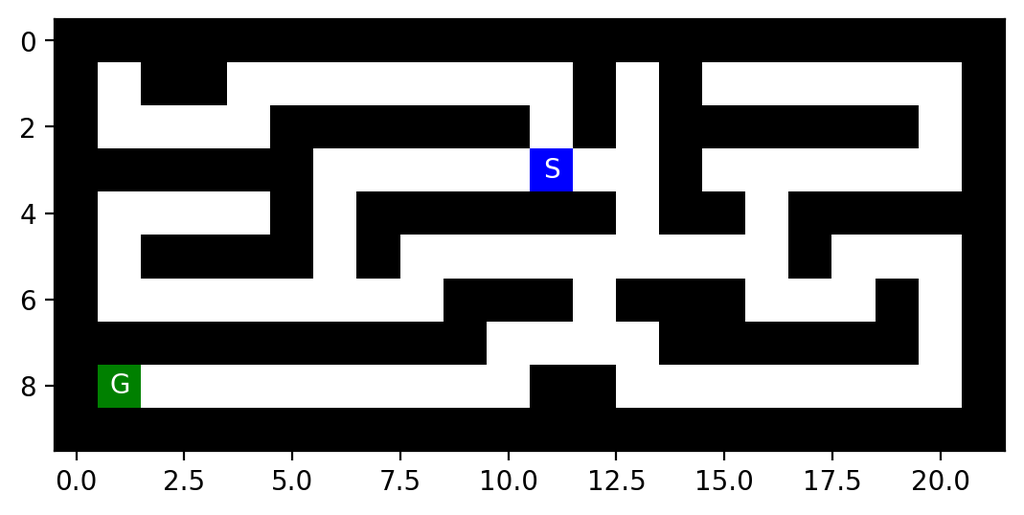

```python
%matplotlib inline
%config InlineBackend.figure_format = 'retina'
# use higher resolution images in notebooks

mh.show_maze(maze)
```

Find the `(x,y)` position of the start and the goal using the helper function `find_pos()`

```python
print("Start location:", mh.find_pos(maze, what = "S"))
print("Goal location:", mh.find_pos(maze, what = "G"))
```

```
Start location: (3, 11)
Goal location: (8, 1)
```

Helper function documentation.

```python
help(mh)
```

```
Help on module maze_helper:

NAME
    maze_helper

DESCRIPTION
    Code for the Maze Assignment by Michael Hahsler
    Usage:
        import maze_helper as mh
        mh.show_some_mazes()

FUNCTIONS
    animate_maze(result, repeat=False)
        Build an animation from a list of mazes. Assumes that results has the elements:
        path, reached, actions and maze_anim with a list of maze arrays.

    find_pos(maze, what='S')
        Find start/goal in a maze and returns the first one.
        Caution: there is no error checking!

        Parameters:
        maze: a array with characters prodced by parse_maze()
        what: the letter to be found ('S' for start and 'G' for goal)

        Returns:
        a tupple (x, y) for the found position.

    look(maze, pos)
        Look at the label of a square with the position as an array of the form (x, y).

    maze_to_matrix(maze)
        convert a maze a numeric numpy array for visualization via imshow.

    parse_maze(maze_str)
        Convert a maze as a string into a 2d numpy array

    show_maze(maze, fontsize=10)
        Display a (parsed) maze as an image.

    welcome()
        Welcome message.

FILE
    /content/maze_helper.py
```

You will need to make a local copy of the module file maze_helper.py in the same folder where your notebook is.

## Tree structure

Here is an implementation of the basic node structure for the search algorithms (see Fig 3.7 on page 73). I have added a method that extracts the path from the root node to the current node. It can be used to get the path when the search is completed.

```python
class Node:
    def __init__(self, pos, parent, action, cost):
        self.pos = tuple(pos)    # the state; positions are (row,col)
        self.parent = parent     # reference to parent node. None means root node.
        self.action = action     # action used in the transition function (root node has None)
        self.cost = cost         # for uniform cost this is the depth. It is also g(n) for A* search

    def __str__(self):
        return f"Node - pos = {self.pos}; action = {self.action}; cost = {self.cost}"

    def get_path_from_root(self):
        """returns nodes on the path from the root to the current node."""
        node = self
        path = [node]

        while not node.parent is None:
            node = node.parent
            path.append(node)

        path.reverse()

        return(path)
```

If needed, then you can add more fields to the class like the heuristic value $h(n)$ or $f(n)$.

Examples for how to create and use a tree and information on memory management can be found here.

# Tasks

The goal is to:

1. Implement the following search algorithms for solving different mazes:
   - Breadth-first search (BFS)
   - Depth-first search (DFS)
   - Greedy best-first search (GBFS)
   - A* search
2. Run each of the above algorithms on the
   - small maze,
   - medium maze,
   - large maze,
   - open maze,
   - wall maze,
   - loops maze,
   - empty maze, and
   - empty 2_maze.
3. For each problem instance and each search algorithm, report the following in a table:
   - The solution and its path cost
   - Total number of nodes expanded
   - Maximum tree depth
   - Maximum size of the frontier
4. Display each solution by marking every maze square (or state) visited and the squares on the final path.

## General [10 Points]

1. Make sure that you use the latest version of this notebook.
2. Your implementation can use libraries like math, numpy, scipy, but not libraries that implement intelligent agents or complete search algorithms. Try to keep the code simple! In this course, we want to learn about the algorithms and we often do not need to use object-oriented design.
3. You notebook needs to be formatted professionally.
   - Add additional markdown blocks for your description, comments in the code, add tables and use mathplotlib to produce charts where appropriate
   - Do not show debugging output or include an excessive amount of output.
   - Check that your submitted file is readable and contains all figures.
4. Document your code. Use comments in the code and add a discussion of how your implementation works and your design choices.

## Task 1: Defining the search problem and determining the problem size [10 Points]

Define the components of the search problem:

- Initial state
- Actions
- Transition model
- Goal state
- Path cost

Use verbal descriptions, variables and equations as appropriate.

*Note:* You can swich the next block from code to Markdown and use formating.

**Initial State**: the tile where agent begine to navigate the maze notated as S (start)

**Actions**: N, S, W, E

**Transition Model**: move from tile A to tile B

**Goal State**: reach tile defined as G (goal)

**Path Cost**: each action has the same cost, let's say c, then path cost = c*p where p is the number of actions taken to complete the given path

Give some estimates for the problem size:

- $n$: state space size
- $d$: depth of the optimal solution
- $m$: maximum depth of tree
- $b$: maximum branching factor

Describe how you would determin these values for a given maze.

$n$: number of tiles/sqaures in the maze (depends on maze size = x * y)

$d$: best case bounded by x * y

$m$: worst case also bounded by x * y

$b$: 4 (based on number of actions, in this case, NSWE)

```python
mh.maze_to_matrix(maze)
```

```
array([[1, 1, 1, 1, 1, 1, 1, 1, 1, 1, 1, 1, 1, 1, 1, 1, 1, 1, 1, 1, 1, 1],
       [1, 0, 1, 1, 0, 0, 0, 0, 0, 0, 0, 0, 1, 0, 1, 0, 0, 0, 0, 0, 0, 1],
       [1, 0, 0, 0, 0, 1, 1, 1, 1, 1, 1, 0, 1, 0, 1, 1, 1, 1, 1, 1, 0, 1],
       [1, 1, 1, 1, 1, 1, 0, 0, 0, 0, 0, 2, 0, 0, 1, 0, 0, 0, 0, 0, 0, 1],
       [1, 0, 0, 0, 0, 1, 0, 1, 1, 1, 1, 1, 1, 0, 1, 1, 0, 1, 1, 1, 1, 1],
       [1, 0, 1, 1, 1, 1, 0, 1, 0, 0, 0, 0, 0, 0, 0, 0, 0, 1, 0, 0, 0, 1],
       [1, 0, 0, 0, 0, 0, 0, 0, 0, 1, 1, 1, 0, 1, 1, 1, 0, 0, 0, 1, 0, 1],
       [1, 1, 1, 1, 1, 1, 1, 1, 1, 1, 0, 0, 0, 0, 1, 1, 1, 1, 1, 1, 0, 1],
       [1, 3, 0, 0, 0, 0, 0, 0, 0, 0, 0, 1, 1, 0, 0, 0, 0, 0, 0, 0, 0, 1],
       [1, 1, 1, 1, 1, 1, 1, 1, 1, 1, 1, 1, 1, 1, 1, 1, 1, 1, 1, 1, 1, 1]])
```

```python
actions = ['N', 'E', 'S', 'W']

def result(pos, action):
  loc = list(pos)
  if (action == 'N'):
    loc[0] -= 1
  elif (action == 'S'):
    loc[0] += 1
  elif (action == 'W'):
    loc[1] -= 1
  elif (action == 'E'):
    loc[1] += 1
  return tuple(loc)
```

## Task 2: Uninformed search: Breadth-first and depth-first [40 Points]

Implement these search strategies. Follow the pseudocode in the textbook/slides. You can use the tree structure shown above to extract the final path from your solution.

Read the following **important notes** carefully:

- You can find maze solving implementations online that use the map to store information. While this is an effective idea for this two-dimensional navigation problem, it typically cannot be used for other search problems. Therefore, follow the textbook and **do not store information in the map.** Only store information in the tree created during search, and use the `reached` and `frontier` data structures where appropriate.
- DSF behavior can be implemented using the BFS tree search algorithm and simply changing the order in which the frontier is expanded (this is equivalent to best-first search with path length as the criterion to expand the next node). However, this would be a big mistake since it combines the bad space complexity of BFS with the bad time complexity of DFS! **To take advantage of the significantly smaller memory footprint of DFS, you need to implement DFS in a different way without a `reached` data structure (often also called `visited` or `explored`) and by releasing the memory for nodes that are not needed anymore.**
- Since the proper implementation of DFS does not use a `reached` data structure, redundant path checking abilities are limited to cycle checking. You need to implement **cycle checking since DSF is incomplete (produces an infinite loop) if cycles cannot be prevented.** You will see in your experiments that cycle checking in open spaces is challenging.

```python
# Expand

def expand(maze, node):#, frontier):
  s = node.pos
  child_nodes = []
  path = [n.pos for n in node.get_path_from_root()]
  #frontier_pos = [x.pos for x in frontier]
  for action in actions:
    s2 = result(s, action)
    if s2 in path:
      continue
    # if s2 in frontier_pos:
    #   continue
    if (maze[s2[0],s2[1]] != 'X'):
      cost = node.cost + 1
      new_node = Node(s2, node, action, cost)
      child_nodes.append(new_node)
  return child_nodes
```

```python
# BFS definition
import matplotlib.pyplot as plt
def BFS(maze, animation = True):
  max_depth = 0
  max_frontier = 0
  depth = 0
  start = mh.find_pos(maze, what = "S")
  goal = mh.find_pos(maze, what = "G")
  results = {'path': [], 'reached': [], 'actions': [], 'maze_anim': []}
  actions = []
  maze_snap = maze.copy()
  maze_anim = []
  node = Node(start, None, None, 0)
  if (node.pos == goal):
    return node
  frontier = [node]
  reached = [start] # total number of nodes
  path = [[start]] # solution and path cost as length of path #########

  while (len(frontier) != 0):
    # print(curr_path)
    if len(frontier) > max_frontier: max_frontier = len(frontier) # max frontier
    node = frontier.pop()
    maze_snap = maze_snap.copy()
    maze_snap[node.pos[0], node.pos[1]] = 'P'
    for child in expand(maze, node):#, frontier):
      #new_path = curr_path
      #print(depth)
      #depth += 1 # track depth
      s = child.pos
      if (child.pos == goal) or (maze[child.pos[0], child.pos[1]] == 'G'):
        maze_snap[p.pos[0], p.pos[1]] = 'P'
        maze_snap[start[0], start[1]] = 'S'
        maze_snap[goal[0], goal[1]] = 'G'
      #mh.show_maze(maze_snap)
        maze_anim.append(maze_snap)
        if animation:
          results['reached'] = reached
          results['actions'] = actions
          results['path'] = path[-1]
          results['maze_anim'] = maze_anim
          # for mz in maze_anim:
          #   mh.show_maze(mz)
          #   print(mh.maze_to_matrix(mz))
          return results, max_depth, max_frontier
      if (node.pos == goal) or (maze[node.pos[0], node.pos[1]] == 'G'):
        curr_path = node.get_path_from_root()
        path.append([n.pos for n in curr_path])
        if animation:
          results['reached'] = reached
          results['actions'] = actions
          results['path'] = path[-1]
          results['maze_anim'] = maze_anim
          return results, max_depth, max_frontier
      if len(maze_anim) > 1: maze_snap = maze_reset
      if s not in reached:
        reached.append(s)
        frontier.insert(0, child)
        actions.append(child.action)
        maze_snap[s[0], s[1]] = 'F'
      curr_path = node.get_path_from_root()
      if len(curr_path) > depth: depth = len(curr_path)
      path.append([n.pos for n in curr_path])
      for p in curr_path:
        if maze_snap[p.pos[0], p.pos[1]] != 'F':
          maze_snap[p.pos[0], p.pos[1]] = 'P'
      maze_snap[start[0], start[1]] = 'S'
      maze_snap[goal[0], goal[1]] = 'G'
      #mh.show_maze(maze_snap)
      maze_anim.append(maze_snap)
      maze_reset = maze_snap.copy()
      for p in curr_path:
        maze_reset[p.pos[0], p.pos[1]] = '.'
      maze_snap[start[0], start[1]] = 'S'
      maze_snap[goal[0], goal[1]] = 'G'
      # if (node.pos[0], node.pos[1]) != (start[0], start[1]):
      #   maze_snap[node.pos[0], node.pos[1]] = '.'
      if depth > max_depth: max_depth = depth

  # if animation:
  #   results['reached'] = reached
  #   results['actions'] = actions
  #   results['path'] = path
  #   results['maze_anim'] = maze_anim
  #   return results results, max_depth, total_nodes, max_frontier
  return -1
```

```python
f = open("small_maze.txt", "r")
#f = open("large_maze.txt", "r")    # this has only one solution!
#f = open("open_maze.txt", "r")
#f = open("empty_maze.txt", "r")
#f = open("empty_2_maze.txt", "r")
#f = open("wall_maze.txt", "r")
#f = open("loops_maze.txt", "r")
#f = open("L_maze.txt", "r")

maze_str = f.read()
maze = mh.parse_maze(maze_str)
maze_result, max_depth, max_frontier = BFS(maze)
print("Path Cost: ", len(maze_result['path']) - 1, "\nTotal Number of Nodes: ", len(maze_result['reached']),
      "\nMax Frontier: ", max_frontier, "\nMax Depth: ", max_depth - 1) # excluding the starting node
mh.animate_maze(maze_result)
```

[output not shown]

[video not shown]

```python
def cycle(node, frontier):
  parent = node.parent
  # if parent.parent == None:
  #   return False
  while parent != None:
    if node.pos == parent.pos:
      return True
    else:
      parent = parent.parent

    #if in fortier remove
  for f in frontier:
    if f.pos == node.pos:
      frontier.remove(f)
      # print("remove: ", f.pos)
      #break
  return False
```